# PredKey Type faster - finish early

8th of March 2018

## What is Predkey?

- PredKey is an innovative and **improved** keyboard
- PredKey **predicts** the next word in the sentence and gives the top three suggestions. With a click/keypress you accept the suggested word without fully typing it
- PredKey works both with **ngrams** (looking the the words typed before) and taking into account the **partial word** the user already has typed
- PredKey uses a dictionary of 20,000 **most common** english words
- PredKey's algorithm is **easy to extend** (e.g. learn new words, new ngrams the user often uses)

## Performance of PredKey

#### How much can you improve when using PredKey?

- 1,000 blog entry samples: avg **42.9 %** less keypresses
- 1,000 news article samples: avg **44.54 %** less keypresses
- 1,000 twitter tweets samples: avg **41.35 %** less keypresses

But how does PredKey perform in a **torture** scenario?

## PredKey in **torture** scenario

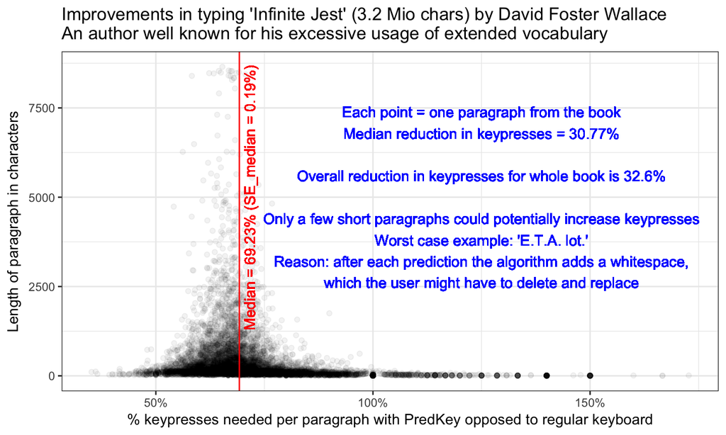

## Resources

- PredKey App online: https://loradim.shinyapps.io/PredKey (Please be aware that the server is a bit slow - predictions might be a bit laggy - locally it runs much better)
- PredKey pitch: https://github.com/Loradim/PredKey
- PredKey on github: https://github.com/Loradim/PredKey

### Contact me

- Email: misterman [at] gmx [dot] de